# Contrasts

Contrasts other than treatment coding for factors with more than two levels have always confused me. I try to design all my own studies to never have more than two levels per categorical factor, but students in my data skills class are always trying to analyse data with three-level categories (or worse).

I thought it was just me, but some recent Twitter discussion showed me I’m not alone. There’s a serious jingle-jangle problem with contrasts. Here are some of the explainers that I found useful (thanks to everyone who recommended them).

1. [Contrasts in R](https://marissabarlaz.github.io/portfolio/contrastcoding/) by Marissa Barlaz
2. [Coding categorical predictor variables in factorial designs](https://talklab.psy.gla.ac.uk/tvw/catpred/) by Dale Barr
3. Contrast Coding in Multiple Regression Analysis by Matthew Davis
4. [R Library Contrast Coding Systems for categorical variables](https://stats.idre.ucla.edu/r/library/r-library-contrast-coding-systems-for-categorical-variables/) by UCLA Statistical Consulting
5. [Rosetta store: Contrasts](https://gamlj.github.io/rosetta_contrasts.html) by GAMLj
6. [Coding Schemes for Categorical Variables](https://phillipalday.com/stats/coding.html) by Phillip Alday
7. [Experimental personality designs: analyzing categorical by continuous variable interactions](https://doi.org/10.1111/j.1467-6494.1996.tb00813.x) by West, Aiken & Krull

## Terminology

Contrasts often have multiple names. The names I’m using try to maintain the relationship with the base R function, apart from anova coding, which was suggested by Dale Barr after I got frustrated that people use so many different labels for that (extremely useful) coding and each of the terms used is also used to refer to totally different codings by others.

[output not shown]

## Faux Contrast Functions

**These functions are under development**

First, we’ll set up a simple experimental design and analyse it with `lm()`. I set `empirical = TRUE` to make interpreting the estimates easier.

```r
df <- sim_design(between = list(pet = c("cat", "dog", "ferret")),
                 n = c(50), mu = c(2, 4, 9), empirical = TRUE)
```

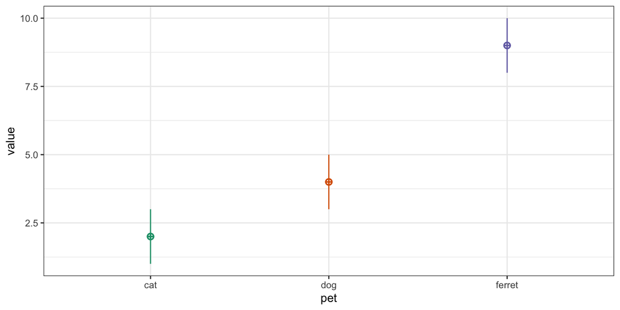

Notice that the default contrast is treatment coding, with “cat” as the baseline condition. The estimate for the intercept is the mean value for cats ($2$), while the term `petdog` is the mean value for dogs minus cats ($4 - 2$), and the term `petferret` is the mean value for ferrets minus cats ($9 - 2$).

Contrasts

lm(y ~ pet, df)

|  | dog | ferret |
| --- | --- | --- |
| cat | 0 | 0 |
| dog | 1 | 0 |
| ferret | 0 | 1 |

| term | estimate | std.error | statistic | p.value |
| --- | --- | --- | --- | --- |
| (Intercept) | 2 | 0.141 | 14.1 | 0 |
| petdog | 2 | 0.200 | 10.0 | 0 |
| petferret | 7 | 0.200 | 35.0 | 0 |

In all the subsequent examples, try putting into words what the estimates for the intercept and terms mean in relation to the mean values for each group in the data.

#### Treatment

Treatment coding (also called dummy coding) sets the mean of the reference group as the intercept. It is straightforward to interpret, especially when your factors have an obvious default or baseline value. This is the same type of coding as the default for factors shown above (unless you change your default using `options()`), but with clearer term labels.

```r
df$pet <- contr_code_treatment(df$pet)
```

Contrasts

lm(y ~ pet, df)

|  | .dog-cat | .ferret-cat |
| --- | --- | --- |
| cat | 0 | 0 |
| dog | 1 | 0 |
| ferret | 0 | 1 |

| term | estimate | std.error | statistic | p.value |
| --- | --- | --- | --- | --- |
| (Intercept) | 2 | 0.141 | 14.1 | 0 |
| pet.dog-cat | 2 | 0.200 | 10.0 | 0 |
| pet.ferret-cat | 7 | 0.200 | 35.0 | 0 |

Each contrast compares one level with the reference level, which defaults to the first level, but you can set with the `base` argument. Now the intercept estimates the mean value for dogs ($4$).

```r
df$pet <- contr_code_treatment(df$pet, base = "dog")
```

Contrasts

lm(y ~ pet, df)

|  | .cat-dog | .ferret-dog |
| --- | --- | --- |
| cat | 1 | 0 |
| dog | 0 | 0 |
| ferret | 0 | 1 |

| term | estimate | std.error | statistic | p.value |
| --- | --- | --- | --- | --- |
| (Intercept) | 4 | 0.141 | 28.3 | 0 |
| pet.cat-dog | -2 | 0.200 | -10.0 | 0 |
| pet.ferret-dog | 5 | 0.200 | 25.0 | 0 |

Set the reference level to the third level (“ferret”).

```r
df$pet <- contr_code_treatment(df$pet, base = 3)
```

Contrasts

lm(y ~ pet, df)

|  | .cat-ferret | .dog-ferret |
| --- | --- | --- |
| cat | 1 | 0 |
| dog | 0 | 1 |
| ferret | 0 | 0 |

| term | estimate | std.error | statistic | p.value |
| --- | --- | --- | --- | --- |
| (Intercept) | 9 | 0.141 | 63.6 | 0 |
| pet.cat-ferret | -7 | 0.200 | -35.0 | 0 |
| pet.dog-ferret | -5 | 0.200 | -25.0 | 0 |

#### Anova

Anova coding is identical to treatment coding, but sets the grand mean as the intercept. Each contrast compares one level with a reference level. This gives us values that are relatively easy to interpret and map onto ANOVA values.

```r
df$pet <- contr_code_anova(df$pet)
```

Contrasts

lm(y ~ pet, df)

|  | .dog-cat | .ferret-cat |
| --- | --- | --- |
| cat | -0.333 | -0.333 |
| dog | 0.667 | -0.333 |
| ferret | -0.333 | 0.667 |

| term | estimate | std.error | statistic | p.value |
| --- | --- | --- | --- | --- |
| (Intercept) | 5 | 0.082 | 61.2 | 0 |
| pet.dog-cat | 2 | 0.200 | 10.0 | 0 |
| pet.ferret-cat | 7 | 0.200 | 35.0 | 0 |

Anova coding with “dog” as the base. How does the interpretation of the terms change?

```r
df$pet <- contr_code_anova(df$pet, base = "dog")
```

Contrasts

lm(y ~ pet, df)

|  | .cat-dog | .ferret-dog |
| --- | --- | --- |
| cat | 0.667 | -0.333 |
| dog | -0.333 | -0.333 |
| ferret | -0.333 | 0.667 |

| term | estimate | std.error | statistic | p.value |
| --- | --- | --- | --- | --- |
| (Intercept) | 5 | 0.082 | 61.2 | 0 |
| pet.cat-dog | -2 | 0.200 | -10.0 | 0 |
| pet.ferret-dog | 5 | 0.200 | 25.0 | 0 |

Anova coding with the third level (“ferret”) as the base.

```r
df$pet <- contr_code_anova(df$pet, base = 3)
```

Contrasts

lm(y ~ pet, df)

|  | .cat-ferret | .dog-ferret |
| --- | --- | --- |
| cat | 0.667 | -0.333 |
| dog | -0.333 | 0.667 |
| ferret | -0.333 | -0.333 |

| term | estimate | std.error | statistic | p.value |
| --- | --- | --- | --- | --- |
| (Intercept) | 5 | 0.082 | 61.2 | 0 |
| pet.cat-ferret | -7 | 0.200 | -35.0 | 0 |
| pet.dog-ferret | -5 | 0.200 | -25.0 | 0 |

#### Sum

Sum coding also sets the grand mean as the intercept. Each contrast compares one level with the grand mean. Therefore, the estimate for `pet_cat-intercept` is the difference between the mean value for cats and the grand mean ($2 - 5$).

```r
df$pet <- contr_code_sum(df$pet)
```

Contrasts

lm(y ~ pet, df)

|  | .cat-intercept | .dog-intercept |
| --- | --- | --- |
| cat | 1 | 0 |
| dog | 0 | 1 |
| ferret | -1 | -1 |

| term | estimate | std.error | statistic | p.value |
| --- | --- | --- | --- | --- |
| (Intercept) | 5 | 0.082 | 61.24 | 0 |
| pet.cat-intercept | -3 | 0.115 | -25.98 | 0 |
| pet.dog-intercept | -1 | 0.115 | -8.66 | 0 |

You can’t compare all levels with the grand mean, and have to omit one level. This is the last level by default, but you can change it with the `omit` argument.

```r
df$pet <- contr_code_sum(df$pet, omit = "dog")
```

Contrasts

lm(y ~ pet, df)

|  | .cat-intercept | .ferret-intercept |
| --- | --- | --- |
| cat | 1 | 0 |
| dog | -1 | -1 |
| ferret | 0 | 1 |

| term | estimate | std.error | statistic | p.value |
| --- | --- | --- | --- | --- |
| (Intercept) | 5 | 0.082 | 61.2 | 0 |
| pet.cat-intercept | -3 | 0.115 | -26.0 | 0 |
| pet.ferret-intercept | 4 | 0.115 | 34.6 | 0 |

Omit the first level (“cat”).

```r
df$pet <- contr_code_sum(df$pet, omit = 1)
```

Contrasts

lm(y ~ pet, df)

|  | .dog-intercept | .ferret-intercept |
| --- | --- | --- |
| cat | -1 | -1 |
| dog | 1 | 0 |
| ferret | 0 | 1 |

| term | estimate | std.error | statistic | p.value |
| --- | --- | --- | --- | --- |
| (Intercept) | 5 | 0.082 | 61.24 | 0 |
| pet.dog-intercept | -1 | 0.115 | -8.66 | 0 |
| pet.ferret-intercept | 4 | 0.115 | 34.64 | 0 |

#### Difference

A slightly different form of contrast coding is difference coding, also called forward, backward, or successive differences coding. It compares each level to the previous one, rather than to a baseline level.

```r
df$pet <- contr_code_difference(df$pet)
```

Contrasts

lm(y ~ pet, df)

|  | .dog-cat | .ferret-dog |
| --- | --- | --- |
| cat | -0.667 | -0.333 |
| dog | 0.333 | -0.333 |
| ferret | 0.333 | 0.667 |

| term | estimate | std.error | statistic | p.value |
| --- | --- | --- | --- | --- |
| (Intercept) | 5 | 0.082 | 61.2 | 0 |
| pet.dog-cat | 2 | 0.200 | 10.0 | 0 |
| pet.ferret-dog | 5 | 0.200 | 25.0 | 0 |

If you want to change which levels are compared, you can re-order the factor levels.

```r
df$pet <- contr_code_difference(df$pet, levels = c("ferret", "cat", "dog"))
```

Contrasts

lm(y ~ pet, df)

|  | .cat-ferret | .dog-cat |
| --- | --- | --- |
| ferret | -0.667 | -0.333 |
| cat | 0.333 | -0.333 |
| dog | 0.333 | 0.667 |

| term | estimate | std.error | statistic | p.value |
| --- | --- | --- | --- | --- |
| (Intercept) | 5 | 0.082 | 61.2 | 0 |
| pet.cat-ferret | -7 | 0.200 | -35.0 | 0 |
| pet.dog-cat | 2 | 0.200 | 10.0 | 0 |

#### Helmert

Helmert coding sets the grand mean as the intercept. Each contrast compares one level with the mean of previous levels. This coding is somewhat different than the results from `stats::contr.helmert()` to make it easier to interpret the estimates. Thus, `pet_ferret-cat.dog` is the mean value for ferrets minus the mean value for cats and dogs averaged together ($9-(2+4)/2$).

```r
df$pet <- contr_code_helmert(df$pet)
```

Contrasts

lm(y ~ pet, df)

|  | .dog-cat | .ferret-cat.dog |
| --- | --- | --- |
| cat | -0.5 | -0.333 |
| dog | 0.5 | -0.333 |
| ferret | 0.0 | 0.667 |

| term | estimate | std.error | statistic | p.value |
| --- | --- | --- | --- | --- |
| (Intercept) | 5 | 0.082 | 61.2 | 0 |
| pet.dog-cat | 2 | 0.200 | 10.0 | 0 |
| pet.ferret-cat.dog | 6 | 0.173 | 34.6 | 0 |

You can change the comparisons by reordering the levels.

```r
df$pet <- contr_code_helmert(df$pet, levels = c("ferret", "dog", "cat"))
```

Contrasts

lm(y ~ pet, df)

|  | .dog-ferret | .cat-ferret.dog |
| --- | --- | --- |
| ferret | -0.5 | -0.333 |
| dog | 0.5 | -0.333 |
| cat | 0.0 | 0.667 |

| term | estimate | std.error | statistic | p.value |
| --- | --- | --- | --- | --- |
| (Intercept) | 5.0 | 0.082 | 61.2 | 0 |
| pet.dog-ferret | -5.0 | 0.200 | -25.0 | 0 |
| pet.cat-ferret.dog | -4.5 | 0.173 | -26.0 | 0 |

#### Polynomial

Polynomial coding is the default for ordered factors in R. We’ll set up a new data simulation with five ordered times.

```r
df <- sim_design(list(time = 1:5),
                 mu = 1:5 * 0.25 + (1:5 - 3)^2 * 0.5,
                 sd = 5, long = TRUE)
```

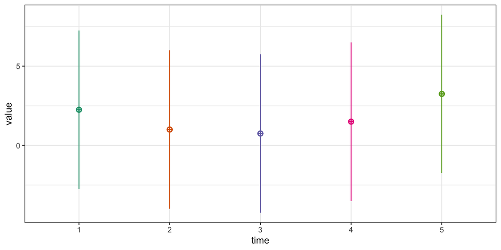

The function `contr_code_poly()` uses `contr.poly()` to set up the polynomial contrasts for the linear (`^1`), quadratic (`^2`), cubic (`^3`), and quartic (`^4`) components.

```r
df$time <- contr_code_poly(df$time)
```

Contrasts

| ^1 | ^2 | ^3 | ^4 |
| --- | --- | --- | --- |
| -0.632 | 0.535 | -0.316 | 0.120 |
| -0.316 | -0.267 | 0.632 | -0.478 |
| 0.000 | -0.535 | 0.000 | 0.717 |
| 0.316 | -0.267 | -0.632 | -0.478 |
| 0.632 | 0.535 | 0.316 | 0.120 |

| term | estimate | std.error | statistic | p.value |
| --- | --- | --- | --- | --- |
| (Intercept) | 2.031 | 0.223 | 9.110 | 0.000 |
| time^1 | 0.239 | 0.498 | 0.480 | 0.631 |
| time^2 | 1.946 | 0.498 | 3.905 | 0.000 |
| time^3 | -0.198 | 0.498 | -0.397 | 0.692 |
| time^4 | -0.004 | 0.498 | -0.009 | 0.993 |

## Add Contrasts

The function `add_contrasts()` lets you add contrasts to a column in a data frame and also adds new columns for each contrast (unless `add_cols = FALSE`). This is especially helpful if you want to test only a subset of the contrasts.

```r
df <- sim_design(list(time = 1:5),
                 mu = 1:5 * 0.25 + (1:5 - 3)^2 * 0.5,
                 sd = 5, long = TRUE, plot = FALSE) %>%
  add_contrast("time", "poly")
```

```r
# test only the linear and quadratic contrasts
lm(y ~ `time^1` + `time^2`, df) %>% broom::tidy()
```

| term | estimate | std.error | statistic | p.value |
| --- | --- | --- | --- | --- |
| (Intercept) | 1.69 | 0.239 | 7.09 | 0.000 |
| `time^1` | 0.78 | 0.534 | 1.46 | 0.145 |
| `time^2` | 2.06 | 0.534 | 3.85 | 0.000 |

You can set `colnames` to change the default column names for the contrasts. This can be useful if you want to add different codings for the same factor or if the default names are too long.

```r
btwn <- list(condition = c("control", "experimental"))

df <- sim_design(between = btwn, n = 1, plot = FALSE) %>%
  add_contrast("condition", "treatment", colnames = "cond.tr") %>%
  add_contrast("condition", "anova", colnames = "cond.aov") %>%
  add_contrast("condition", "difference", colnames = "cond.dif") %>%
  add_contrast("condition", "sum", colnames = "cond.sum") %>%
  add_contrast("condition", "helmert", colnames = "cond.hmt") %>%
  add_contrast("condition", "poly", colnames = "cond.poly")
```

| id | condition | y | cond.tr | cond.aov | cond.dif | cond.sum | cond.hmt | cond.poly |
| --- | --- | --- | --- | --- | --- | --- | --- | --- |
| S1 | control | 0.697 | 0 | -0.5 | -0.5 | 1 | -0.5 | -0.707 |
| S2 | experimental | 0.512 | 1 | 0.5 | 0.5 | -1 | 0.5 | 0.707 |

However, if a new column has a duplicate name to an existing column, `add_contrast()` will automatically add a contrast suffix to the new column.

```r
btwn <- list(pet = c("cat", "dog", "ferret"))

df <- sim_design(between = btwn, n = 1, plot = FALSE) %>%
  add_contrast("pet", "treatment") %>%
  add_contrast("pet", "anova") %>%
  add_contrast("pet", "sum") %>%
  add_contrast("pet", "difference") %>%
  add_contrast("pet", "helmert") %>%
  add_contrast("pet", "poly")
```

| id | pet | y | pet.dog-cat | pet.ferret-cat | pet.dog-cat.aov | pet.ferret-cat.aov | pet.cat-intercept | pet.dog-intercept | pet.dog-cat.dif | pet.ferret-dog | pet.dog-cat.hmt | pet.ferret-cat.dog | pet^1 | pet^2 |
| --- | --- | --- | --- | --- | --- | --- | --- | --- | --- | --- | --- | --- | --- | --- |
| S1 | cat | -0.72 | 0 | 0 | -0.33 | -0.33 | 1 | 0 | -0.67 | -0.33 | -0.5 | -0.33 | -0.71 | 0.41 |
| S2 | dog | -0.36 | 1 | 0 | 0.67 | -0.33 | 0 | 1 | 0.33 | -0.33 | 0.5 | -0.33 | 0.00 | -0.82 |
| S3 | ferret | -1.43 | 0 | 1 | -0.33 | 0.67 | -1 | -1 | 0.33 | 0.67 | 0.0 | 0.67 | 0.71 | 0.41 |

## Examples

### 2x2 Design

Let’s use simulated data with `empirical = TRUE` to explore how to interpret interactions between two 2-level factors coded in different ways.

```r
mu <- c(0, 4, 6, 10)
df <- sim_design(between = list(time = c("am", "pm"),
                                pet = c("cat", "dog")),
                 n = c(50, 60, 70, 80), mu = mu, empirical = TRUE)
```

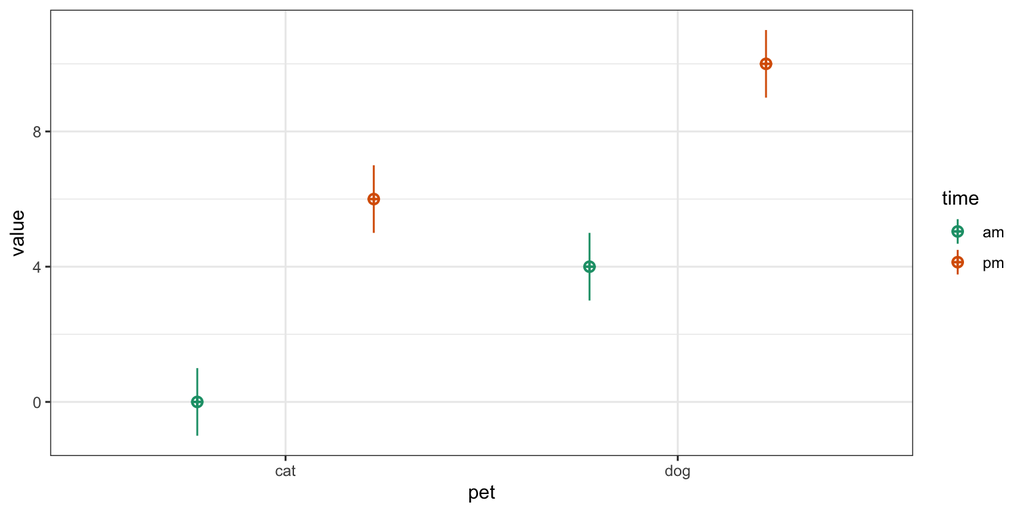

The table below shows the cell and marginal means. The notation $Y_{..}$ is used to denote a mean for a specific grouping. The `.` is used to indicate the mean over all groups of that factor; `Y..` is the grand mean. While you’ll usually see the subscripts written as numbers to indicate the factor levels, we’re using letters here so you don’t have to keep referring to the order of factors and levels.

|  | cat | dog | mean |
| --- | --- | --- | --- |
| **am** | $Y_{ca} = 0$ | $Y_{da} = 4$ | $Y_{.a} = 2$ |
| **pm** | $Y_{cp} = 6$ | $Y_{dp} = 10$ | $Y_{.p} = 8$ |
| **mean** | $Y_{c.} = 3$ | $Y_{d.} = 7$ | $Y_{..} = 5$ |

##### Treatment

| term | interpretation | formula | value |
| --- | --- | --- | --- |
| intercept | cat when am | $Y_{ca}$ | $0$ |
| pet.dog-cat | dog minus cat, when am | $Y_{da} - Y_{ca}$ | $4 - 0 = 4$ |
| time.pm-am | pm minus am, for cats | $Y_{cp} - Y_{ca}$ | $6 - 0 = 6$ |
| pet.dog-cat:time.pm-am | dog minus cat when pm, minus dog minus cat when am | $(Y_{dp} - Y_{cp}) - (Y_{da} - Y_{ca})$ | $(10 - 6) - (4 - 0) = 0$ |

```r
df %>%
  add_contrast("pet", "treatment") %>%
  add_contrast("time", "treatment") %>%
  lm(y ~ pet * time, .) %>%
  broom::tidy() %>% kable() %>% kable_styling()
```

| term | estimate | std.error | statistic | p.value |
| --- | --- | --- | --- | --- |
| (Intercept) | 0 | 0.141 | 0.0 | 1 |
| pet.dog-cat | 4 | 0.191 | 20.9 | 0 |
| time.pm-am | 6 | 0.185 | 32.4 | 0 |
| pet.dog-cat:time.pm-am | 0 | 0.252 | 0.0 | 1 |

##### Anova

| term | interpretation | formula | value |
| --- | --- | --- | --- |
| intercept | grand mean | $Y_{..}$ | $5$ |
| pet.dog-cat | mean dog minus mean cat | $Y_{d.} - Y_{c.}$ | $7 - 3 = 4$ |
| time.pm-am | mean pm minus mean am | $Y_{.p} - Y_{.a}$ | $8 - 2 = 6$ |
| pet.dog-cat:time.pm-am | dog minus cat when pm, minus dog minus cat when am | $(Y_{dp} - Y_{cp}) - (Y_{da} - Y_{ca})$ | $(10 - 6) - (4 - 0) = 0$ |

```r
df %>%
  add_contrast("pet", "anova") %>%
  add_contrast("time", "anova") %>%
  lm(y ~ pet * time, .) %>%
  broom::tidy() %>% kable() %>% kable_styling()
```

| term | estimate | std.error | statistic | p.value |
| --- | --- | --- | --- | --- |
| (Intercept) | 5 | 0.063 | 79.4 | 0 |
| pet.dog-cat | 4 | 0.126 | 31.8 | 0 |
| time.pm-am | 6 | 0.126 | 47.6 | 0 |
| pet.dog-cat:time.pm-am | 0 | 0.252 | 0.0 | 1 |

##### Sum

[output not shown]

```r
df %>%
  add_contrast("pet", "sum") %>%
  add_contrast("time", "sum") %>%
  lm(y ~ pet * time, .) %>%
  broom::tidy() %>% kable() %>% kable_styling()
```

| term | estimate | std.error | statistic | p.value |
| --- | --- | --- | --- | --- |
| (Intercept) | 5 | 0.063 | 79.4 | 0 |
| pet.cat-intercept | -2 | 0.063 | -31.8 | 0 |
| time.am-intercept | -3 | 0.063 | -47.6 | 0 |
| pet.cat-intercept:time.am-intercept | 0 | 0.063 | 0.0 | 1 |

##### Difference

| term | interpretation | formula | value |
| --- | --- | --- | --- |
| intercept | grand mean | $Y_{..}$ | $5$ |
| pet.dog-cat | mean dog minus mean cat | $Y_{d.} - Y_{c.}$ | $7 - 3 = 4$ |
| time.pm-am | mean pm minus mean am | $Y_{.p} - Y_{.a}$ | $8 - 2 = 6$ |
| pet.dog-cat:time.pm-am | dog minus cat when pm, minus dog minus cat when am | $(Y_{dp} - Y_{cp}) - (Y_{da} - Y_{ca})$ | $(10 - 6) - (4 - 0) = 0$ |

```r
df %>%
  add_contrast("pet", "difference") %>%
  add_contrast("time", "difference") %>%
  lm(y ~ pet * time, .) %>%
  broom::tidy() %>% kable() %>% kable_styling()
```

| term | estimate | std.error | statistic | p.value |
| --- | --- | --- | --- | --- |
| (Intercept) | 5 | 0.063 | 79.4 | 0 |
| pet.dog-cat | 4 | 0.126 | 31.8 | 0 |
| time.pm-am | 6 | 0.126 | 47.6 | 0 |
| pet.dog-cat:time.pm-am | 0 | 0.252 | 0.0 | 1 |

##### Helmert

| term | interpretation | formula | value |
| --- | --- | --- | --- |
| intercept | grand mean | $Y_{..}$ | $5$ |
| pet.dog-cat | mean dog minus mean cat | $Y_{d.} - Y_{c.}$ | $7 - 3 = 4$ |
| time.pm-am | mean pm minus mean am | $Y_{.p} - Y_{.a}$ | $8 - 2 = 6$ |
| pet.dog-cat:time.pm-am | dog minus cat when pm, minus dog minus cat when am | $(Y_{dp} - Y_{cp}) - (Y_{da} - Y_{ca})$ | $(10 - 6) - (4 - 0) = 0$ |

```r
df %>%
  add_contrast("pet", "helmert") %>%
  add_contrast("time", "helmert") %>%
  lm(y ~ pet * time, .) %>%
  broom::tidy() %>% kable() %>% kable_styling()
```

| term | estimate | std.error | statistic | p.value |
| --- | --- | --- | --- | --- |
| (Intercept) | 5 | 0.063 | 79.4 | 0 |
| pet.dog-cat | 4 | 0.126 | 31.8 | 0 |
| time.pm-am | 6 | 0.126 | 47.6 | 0 |
| pet.dog-cat:time.pm-am | 0 | 0.252 | 0.0 | 1 |

### 2x3 Design

Let’s use simulated data with `empirical = TRUE` to explore how to interpret interactions between a 2-level factor and a 3-level factor coded in different ways.

```r
mu <- c(0, 5, 7, 6, 2, 1)
df <- sim_design(between = list(time = c("am", "pm"),
                                pet = c("cat", "dog", "ferret")),
                 n = c(50, 60, 70, 80, 90, 100), mu = mu, empirical = TRUE)
```

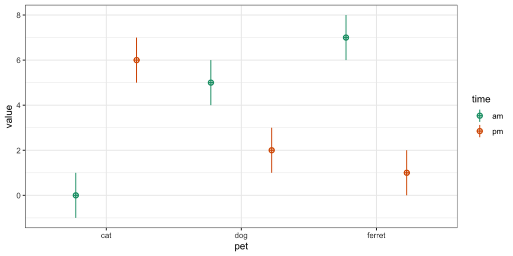

|  | cat | dog | ferret | mean |
| --- | --- | --- | --- | --- |
| **am** | $Y_{ca} = 0$ | $Y_{da} = 5$ | $Y_{fa} = 7$ | $Y_{.a} = 4$ |
| **pm** | $Y_{cp} = 6$ | $Y_{dp} = 2$ | $Y_{fp} = 1$ | $Y_{.p} = 3$ |
| **mean** | $Y_{c.} = 3$ | $Y_{d.} = 3.5$ | $Y_{f.} = 4$ | $Y_{..} = 3.5$ |

##### Treatment

| term | interpretation | formula | value |
| --- | --- | --- | --- |
| intercept | cat when am | $Y_{ca}$ | $0$ |
| pet.dog-cat | dog minus cat, when am | $Y_{da} - Y_{ca}$ | $5 - 0 = 5$ |
| pet.ferret-cat | ferret minus cat, when am | $Y_{fa} - Y_{ca}$ | $7 - 0 = 7$ |
| time.pm-am | pm minus am, for cats | $Y_{cp} - Y_{ca}$ | $6 - 0 = 6$ |
| pet.dog-cat:time.pm-am | dog minus cat when pm, minus dog minus cat when am | $(Y_{dp} - Y_{cp}) - (Y_{da} - Y_{ca})$ | $(2 - 6) - (5 - 0) = -9$ |
| pet.ferret-cat:time.pm-am | ferret minus cat when pm, minus ferret minus cat when am | $(Y_{fp} - Y_{cp}) - (Y_{fa} - Y_{ca})$ | $(1 - 6) - (7 - 0) = -12$ |

```r
df %>%
  add_contrast("pet", "treatment") %>%
  add_contrast("time", "treatment") %>%
  lm(y ~ pet * time, .) %>%
  broom::tidy() %>% kable() %>% kable_styling()
```

| term | estimate | std.error | statistic | p.value |
| --- | --- | --- | --- | --- |
| (Intercept) | 0 | 0.141 | 0.0 | 1 |
| pet.dog-cat | 5 | 0.191 | 26.1 | 0 |
| pet.ferret-cat | 7 | 0.185 | 37.8 | 0 |
| time.pm-am | 6 | 0.180 | 33.3 | 0 |
| pet.dog-cat:time.pm-am | -9 | 0.246 | -36.7 | 0 |
| pet.ferret-cat:time.pm-am | -12 | 0.238 | -50.4 | 0 |

##### Anova

| term | interpretation | formula | value |
| --- | --- | --- | --- |
| intercept | grand mean | $Y_{..}$ | $3.5$ |
| pet.dog-cat | mean dog minus mean cat | $Y_{d.} - Y_{c.}$ | $3.5 - 3 = 0.5$ |
| pet.ferret-cat | mean ferret minus mean cat | $Y_{f.} - Y_{c.}$ | $4 - 3 = 1$ |
| time.pm-am | mean pm minus mean am | $Y_{.p} - Y_{.a}$ | $3 - 4 = -1$ |
| pet.dog-cat:time.pm-am | dog minus cat when pm, minus dog minus cat when am | $(Y_{dp} - Y_{cp}) - (Y_{da} - Y_{ca})$ | $(2 - 6) - (5 - 0) = -9$ |
| pet.ferret-cat:time.pm-am | ferret minus cat when pm, minus ferret minus cat when am | $(Y_{fp} - Y_{cp}) - (Y_{fa} - Y_{ca})$ | $(1 - 6) - (7 - 0) = -12$ |

```r
df %>%
  add_contrast("pet", "anova") %>%
  add_contrast("time", "anova") %>%
  lm(y ~ pet * time, .) %>%
  broom::tidy() %>% kable() %>% kable_styling()
```

| term | estimate | std.error | statistic | p.value |
| --- | --- | --- | --- | --- |
| (Intercept) | 3.5 | 0.048 | 72.22 | 0 |
| pet.dog-cat | 0.5 | 0.123 | 4.07 | 0 |
| pet.ferret-cat | 1.0 | 0.119 | 8.39 | 0 |
| time.pm-am | -1.0 | 0.097 | -10.32 | 0 |
| pet.dog-cat:time.pm-am | -9.0 | 0.246 | -36.66 | 0 |
| pet.ferret-cat:time.pm-am | -12.0 | 0.238 | -50.36 | 0 |

##### Sum

[output not shown]

```r
df %>%
  add_contrast("pet", "sum") %>%
  add_contrast("time", "sum") %>%
  lm(y ~ pet * time, .) %>%
  broom::tidy() %>% kable() %>% kable_styling()
```

| term | estimate | std.error | statistic | p.value |
| --- | --- | --- | --- | --- |
| (Intercept) | 3.5 | 0.048 | 72.22 | 0 |
| pet.cat-intercept | -0.5 | 0.071 | -7.03 | 0 |
| pet.dog-intercept | 0.0 | 0.068 | 0.00 | 1 |
| time.am-intercept | 0.5 | 0.048 | 10.32 | 0 |
| pet.cat-intercept:time.am-intercept | -3.5 | 0.071 | -49.22 | 0 |
| pet.dog-intercept:time.am-intercept | 1.0 | 0.068 | 14.64 | 0 |

##### Difference

| term | interpretation | formula | value |
| --- | --- | --- | --- |
| intercept | grand mean | $Y_{..}$ | $3.5$ |
| pet.dog-cat | mean dog minus mean cat | $Y_{d.} - Y_{c.}$ | $3.5 - 3 = 0.5$ |
| pet.ferret-dog | mean ferret minus mean dog | $Y_{f.} - Y_{d.}$ | $4 - 3.5 = 0.5$ |
| time.pm-am | mean pm minus mean am | $Y_{.p} - Y_{.a}$ | $3 - 4 = -1$ |
| pet.dog-cat:time.pm-am | dog minus cat when pm, minus dog minus cat when am | $(Y_{dp} - Y_{cp}) - (Y_{da} - Y_{ca})$ | $(2 - 6) - (5 - 0) = -9$ |
| pet.ferret-dog:time.pm-am | ferret minus dog when pm, minus ferret minus dog when am | $(Y_{fp} - Y_{dp}) - (Y_{fa} - Y_{da})$ | $(1 - 2) - (7 - 5) = -3$ |

```r
df %>%
  add_contrast("pet", "difference") %>%
  add_contrast("time", "difference") %>%
  lm(y ~ pet * time, .) %>%
  broom::tidy() %>% kable() %>% kable_styling()
```

| term | estimate | std.error | statistic | p.value |
| --- | --- | --- | --- | --- |
| (Intercept) | 3.5 | 0.048 | 72.22 | 0 |
| pet.dog-cat | 0.5 | 0.123 | 4.07 | 0 |
| pet.ferret-dog | 0.5 | 0.114 | 4.38 | 0 |
| time.pm-am | -1.0 | 0.097 | -10.32 | 0 |
| pet.dog-cat:time.pm-am | -9.0 | 0.246 | -36.66 | 0 |
| pet.ferret-dog:time.pm-am | -3.0 | 0.228 | -13.15 | 0 |

##### Helmert

| term | interpretation | formula | value |
| --- | --- | --- | --- |
| intercept | grand mean | $Y_{..}$ | $3.5$ |
| pet.dog-cat | mean dog minus mean cat | $Y_{d.} - Y_{c.}$ | $3.5 - 3 = 0.5$ |
| pet.ferret-cat.dog | mean ferret minus mean of cat and dog | $Y_{f.} - \frac{Y_{c.} + Y_{d.}}{2}$ | $4 - \frac{3 + 3.5}{2} = 0.75$ |
| time.pm-am | mean pm minus mean am | $Y_{.p} - Y_{.a}$ | $3 - 4 = -1$ |
| pet.dog-cat:time.pm-am | dog minus cat when pm, minus dog minus cat when am | $(Y_{dp} - Y_{cp}) - (Y_{da} - Y_{ca})$ | $(2 - 6) - (5 - 0) = -9$ |
| pet.ferret-cat.dog:time.pm-am | ferret minus mean of cat and dog when pm, minus ferret minus mean of cat and dog when am | $(Y_{fp} - \frac{Y_{cp} + Y_{dp}}{2}) - (Y_{fa} - \frac{Y_{ca} + Y_{da}}{2})$ | $(1 - \frac{6 + 2}{2}) - (7 - \frac{0 + 5}{2}) = -7.5$ |

```r
df %>%
  add_contrast("pet", "helmert") %>%
  add_contrast("time", "helmert") %>%
  lm(y ~ pet * time, .) %>%
  broom::tidy() %>% kable() %>% kable_styling()
```

| term | estimate | std.error | statistic | p.value |
| --- | --- | --- | --- | --- |
| (Intercept) | 3.50 | 0.048 | 72.22 | 0 |
| pet.dog-cat | 0.50 | 0.123 | 4.07 | 0 |
| pet.ferret-cat.dog | 0.75 | 0.099 | 7.56 | 0 |
| time.pm-am | -1.00 | 0.097 | -10.32 | 0 |
| pet.dog-cat:time.pm-am | -9.00 | 0.246 | -36.66 | 0 |
| pet.ferret-cat.dog:time.pm-am | -7.50 | 0.198 | -37.81 | 0 |

**N.B. In this case, difference coding is identical to anova coding except that the second pet contrast is ferret versus dog instead of ferret versus cat.**

### 3x3 Design

Please just don’t. You’re going to break my head.